# ASOIAF: How related are Jon and Danny?

# Introduction

Just how closely related are Jon Snow and Daenerys Targaryen? According to the lore of *A Song of Ice and Fire*, Daenerys is Jon’s paternal aunt. This would suggest a theoretical genetic relatedness of 0.25, assuming a simple pedigree and no inbreeding. But with tangled ancestries and potentially missing information, how confident can we be in that estimate?

In this vignette, we use the `BGmisc` package to reconstruct the *ASOIAF* pedigree from the `ggpedigree` package, handle incomplete parentage data, and compute additive genetic and common nuclear relatedness. We’ll focus on Jon and Daenerys as a case study, but the methods generalize to any characters in the provided dataset.

## Load Packages and Data

We begin by loading the required libraries and examining the structure of the built-in `ASOIAF` pedigree.

```r
library(BGmisc)
library(tidyverse)
library(ggpedigree)
data(ASOIAF, package = "ggpedigree")
```

The ASOIAF dataset includes character IDs, names, family identifiers, and parent identifiers for a subset of characters drawn from the *A Song of Ice and Fire* canon.

```r
head(ASOIAF)
```

```
##   id famID momID dadID          name sex
## 1  1     1   566   564   Walder Frey   M
## 2  2     1    NA    NA   Perra Royce   F
## 3  3     1     2     1  Stevron Frey   M
## 4  4     1     2     1    Emmon Frey   M
## 5  5     1     2     1    Aenys Frey   M
## 6  6     1    NA    NA Corenna Swann   F
##                                                   url twinID zygosity
## 1   https://awoiaf.westeros.org/index.php/Walder_Frey     NA     <NA>
## 2   https://awoiaf.westeros.org/index.php/Perra_Royce     NA     <NA>
## 3  https://awoiaf.westeros.org/index.php/Stevron_Frey     NA     <NA>
## 4    https://awoiaf.westeros.org/index.php/Emmon_Frey     NA     <NA>
## 5    https://awoiaf.westeros.org/index.php/Aenys_Frey     NA     <NA>
## 6 https://awoiaf.westeros.org/index.php/Corenna_Swann     NA     <NA>
```

## Prepare and Validate Sex Codes

Many pedigree-based algorithms rely on biological sex for downstream calculationss and visualization. We use `checkSex()` to inspect the sex variable, repairing inconsistencies programmatically.

```r
df_got <- checkSex(ASOIAF,
  code_male = 1,
  code_female = 0,
  verbose = FALSE, repair = TRUE
)
```

## Compute Relatedness Matrices

With validated pedigree data, we can now compute two distinct relationship matrices:

- Additive genetic relatedness (add): Proportion of shared additive genetic variance between individuals.
- Common nuclear relatedness (cn): Indicates shared full-sibling (nuclear family) environments.

These are derived using `ped2add`() and `ped2cn`(), respectively. Both functions rely on internal graph traversal and adjacency structures. In this case:

- We specify isChild_method = “partialparent” to allow inclusion of dyads where one parent is unknown.
- We choose adjacency_method = “direct” for the additive matrix to optimize for computational speed.
- For the common nuclear matrix, we use adjacency_method = “indexed”, which is slower but necessary for resolving sibling-group structures.
- We set `sparse = TRUE` to return compressed sparse matrices rather than full (dense) formats.

```r
add <- ped2com(df_got,
  isChild_method = "partialparent",
  component = "additive",
  adjacency_method = "direct",
  sparse = TRUE,
  mz_twins = TRUE
)

mt <- ped2com(df_got,
  isChild_method = "partialparent",
  component = "mitochondrial",
  adjacency_method = "direct",
  sparse = TRUE
)

cn <- ped2cn(df_got,
  isChild_method = "partialparent",
  adjacency_method = "indexed",
  sparse = TRUE
)
```

Each of these matrices is square, with dimensions equal to the number of individuals in the pedigree. The entries represent pairwise relatedness coefficients.

To verify the matrices, we can plot their sparsity patterns:

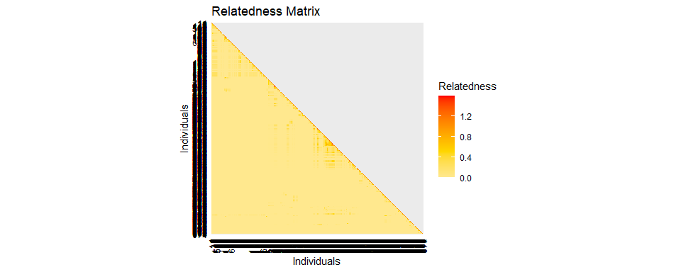

```r
par(mfrow = c(1, 3))
ggRelatednessMatrix(as.matrix(add),
  config = list(
    matrix_color_palette = c("white", "gold", "red"),
    color_scale_midpoint = 0.5,
    matrix_cluster = TRUE,
    plot_title = "Relatedness Matrix",
    axis_x_label = "Individuals",
    axis_y_label = "Individuals",
    label_include = FALSE
  )
)
```

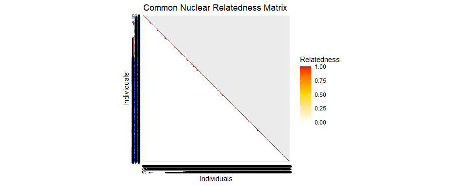

```r
ggRelatednessMatrix(as.matrix(cn),
  config = list(
    matrix_color_palette = c("white", "lightblue", "blue"),
    color_scale_midpoint = 0.5,
    matrix_cluster = TRUE,
    plot_title = "Common Nuclear Relatedness Matrix",
    axis_x_label = "Individuals",
    axis_y_label = "Individuals",
    axis_text_size = 8
  )
)
```

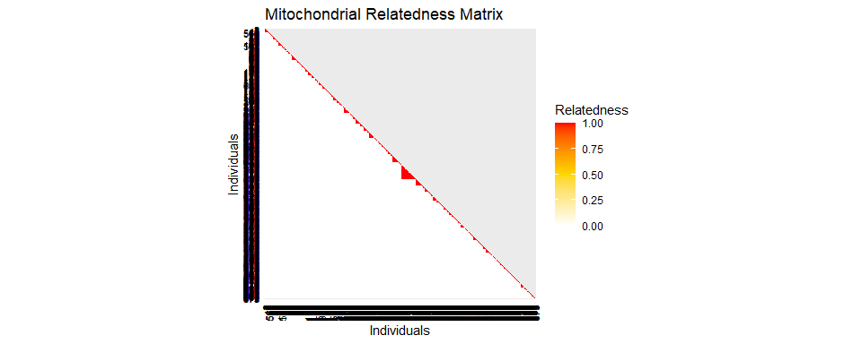

```r
ggRelatednessMatrix(as.matrix(mt),
  config = list(
    matrix_color_palette = c("white", "lightgreen", "darkgreen"),
    color_scale_midpoint = 0.5,
    matrix_cluster = TRUE,
    plot_title = "Mitochondrial Relatedness Matrix",
    axis_x_label = "Individuals",
    axis_y_label = "Individuals",
    axis_text_size = 8
  )
)
```

```r
par(mfrow = c(1, 1))
```

## Convert to Pairwise Format

For interpretability, we convert these square matrices into long-format tables using `com2links()`. This function returns a dataframe where each row represents a unique pair of individuals, including their additive and common nuclear coefficients.

```r
df_links <- com2links(
  writetodisk = FALSE,
  ad_ped_matrix = add, cn_ped_matrix = cn, mit_ped_matrix = mt,
  drop_upper_triangular = TRUE
) # %>%
#  filter(ID1 != ID2)
```

The function can return the entire matrix or just the lower triangular part, which is often sufficient for our purposes. Setting `drop_upper_triangular = TRUE` ensures we only retain one entry per dyad, since the matrices are symmetric. We also keep the data in memory by setting `writetodisk = FALSE`.

## Locate Jon and Daenerys

We next identify the rows in the pairwise relatedness table that correspond to Jon Snow and Daenerys Targaryen. First, we retrieve their individual IDs:

```r
# Find the IDs of Jon Snow and Daenerys Targaryen

jon_id <- df_got %>%
  filter(name == "Jon Snow") %>%
  pull(ID)

dany_id <- df_got %>%
  filter(name == "Daenerys Targaryen") %>%
  pull(ID)
```

We can then filter the pairwise relatedness table to isolate the dyad of interest:

```r
jon_dany_row <- df_links %>%
  filter(ID1 == jon_id | ID2 == jon_id) %>%
  filter(ID1 %in% dany_id | ID2 %in% dany_id) %>% # round to nearest 4th decimal
  mutate(across(c(addRel, mitRel, cnuRel), ~ round(.x, 4)))

jon_dany_row
```

```
##   ID1 ID2 addRel mitRel cnuRel
## 1 206 211 0.5031      0      0
## 2 211 304 0.0562      0      0
```

This table contains the additive nuclear relatedness estimates for Jon and Daenerys. If the pedigree reflects their canonical aunt-nephew relationship and is free from… complications, we’d expect to see an additive coefficient close to 0.25. However, the value is 0.5031, indicating a more complex relationship and in line with how related we would expect full siblings to be.

Likewise, when we examine the relatedness for a different pair, such as Rhaenyra Targaryen and Damemon Targaryen, we can see how the relatedness coefficients vary across different characters in the dataset.

```r
rhaenyra_id <- df_got %>%
  filter(name == "Rhaenyra Targaryen") %>%
  pull(ID)
daemon_id <- df_got %>%
  filter(name == "Daemon Targaryen") %>%
  pull(ID)

rhaenyra_daemon_row <- df_links %>%
  filter(ID1 == rhaenyra_id | ID2 == rhaenyra_id) %>%
  filter(ID1 %in% daemon_id | ID2 %in% daemon_id) %>% # round to 4th decimal
  mutate(across(c(addRel, mitRel, cnuRel), ~ round(.x, 4)))

rhaenyra_daemon_row
```

```
##   ID1 ID2 addRel mitRel cnuRel
## 1 339 536 0.7355      1      0
```

## Plotting the Pedigree with Incomplete Parental Information

Many real-world and fictional pedigrees contain individuals with unknown or partially known parentage. In such cases, plotting tools typically fail unless these gaps are handled. We use `checkParentIDs()` to:

- Identify individuals with one known parent and one missing
- Create “phantom” placeholders for the missing parent
- Optionally repair and harmonize parent fields

To facilitate plotting, we check for individuals with one known parent but a missing other. For those cases, we assign a placeholder ID to the missing parent.

```r
df_repaired <- checkParentIDs(df_got, # %>% filter(famID == 1),
  addphantoms = TRUE,
  repair = TRUE,
  parentswithoutrow = FALSE,
  repairsex = FALSE
) %>% mutate(
  # famID = 1,
  affected = case_when(
    ID %in% c(jon_id, dany_id, 339) ~ TRUE,
    TRUE ~ FALSE
  )
)
```

```
## REPAIR IN EARLY ALPHA
```

This code creates new IDs for individuals with one known parent and a missing other. It checks if either `momID` or `dadID` is missing, and if so, it assigns a new ID based on the row number. This allows us to visualize the pedigree even when some parental information is incomplete. Now we can check the repaired pedigree for unique IDs and parent-child relationships.

```r
checkIDs <- checkIDs(df_repaired, verbose = TRUE)
```

```
## Standardizing column names...
```

```
## Checking IDs...
## Step 1: Checking for unique IDs...
## All IDs are unique.
## Step 2: Checking for within row duplicats...
## No within row duplicates found.
## Validation Results:
```

[output not shown]

```r
# checkIDs
```

```r
# Check for unique IDs and parent-child relationships
checkPedigreeNetwork <- checkPedigreeNetwork(df_repaired,
  personID = "ID",
  momID = "momID",
  dadID = "dadID",
  verbose = TRUE
)
```

```
## No individuals with more than two parents detected.
```

```
## No duplicate edges detected.
```

```
## No cyclic relationships detected.
```

```r
checkPedigreeNetwork
```

```
## $individuals_with_excess_parents
## character(0)
##
## $duplicate_edges
##      [,1] [,2]
##
## $is_acyclic
## [1] TRUE
```

As we can see, the repaired pedigree now has unique IDs for all individuals, and the parent-child relationships are intact. The function `checkIDs()` confirms that all IDs are unique, while `checkPedigreeNetwork()` verifies that there are no structural issues like individuals with more than two parents or cyclic relationships.

## Visualize the Pedigree

This function provides a more flexible and customizable way to visualize pedigrees, allowing for easy integration with other `ggplot2` functions relative to kinship2’s pedigree plotting functions.

[figure not shown]

```r
library(ggpedigree)

df_repaired_renamed <- df_repaired %>% rename(
  personID = ID
)
plt <- ggpedigree(df_repaired_renamed,
  overlay_column = "affected",
  personID = "personID",
  interactive = FALSE,
  config = list(
    overlay_include = TRUE,
    point_size = .75,
    code_male = "M",
    ped_width = 17,
    label_nudge_y = -.25,
    include_labels = TRUE,
    label_method = "geom_text",
    # segment_self_color = "purple",
    sex_color_include = FALSE,
    focal_fill_personID = 353, # 339, # 353,
    focal_fill_include = TRUE,
    tooltip_columns = c("personID", "name", "focal_fill"),
    focal_fill_force_zero = TRUE,
    focal_fill_mid_color = "orange",
    focal_fill_low_color = "#9F2A63FF",
    focal_fill_legend_title = "Relatedness to \nAegon Targaryen",
    focal_fill_na_value = "black",
    value_rounding_digits = 4
  )
)

plt
```

```r
# reduce file size for CRAN
# if (interactive()) {
# If running interactively, use plotly::partial_bundle
# to reduce file size for CRAN
#  plotly::partial_bundle(plt)
# } else {
#  plotly::partial_bundle(plt, local = TRUE)
# }
```

This plot can provide an interactive visualization of the ASOIAF pedigree (if interactive is set to TRUE), allowing users to explore relationships and affected status. The focal individual is highlighted, and tooltips provide additional information about each character.

## Conclusion

In this vignette, we demonstrated how to reconstruct and analyze the *A Song of Ice and Fire* pedigree using the `BGmisc` package. We computed additive and common nuclear relatedness coefficients for key characters, revealing the complexities of their relationships. By handling incomplete parentage data and visualizing the pedigree, we provided a comprehensive overview of how related Jon Snow and Daenerys Targaryen truly are.